# Майнор "Интеллектуальный анализ данных"

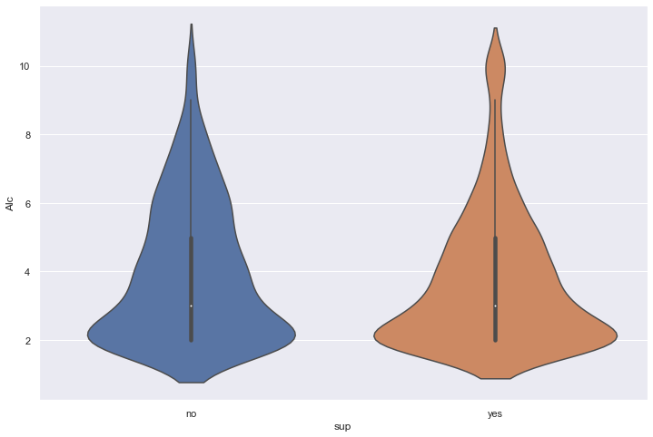

```python
sns.violinplot(x='sup', y='Alc', data=data)
```

```
no          AxesSubplot(0.1,0.15;0.363636x0.75)
yes    AxesSubplot(0.536364,0.15;0.363636x0.75)
dtype: object
```

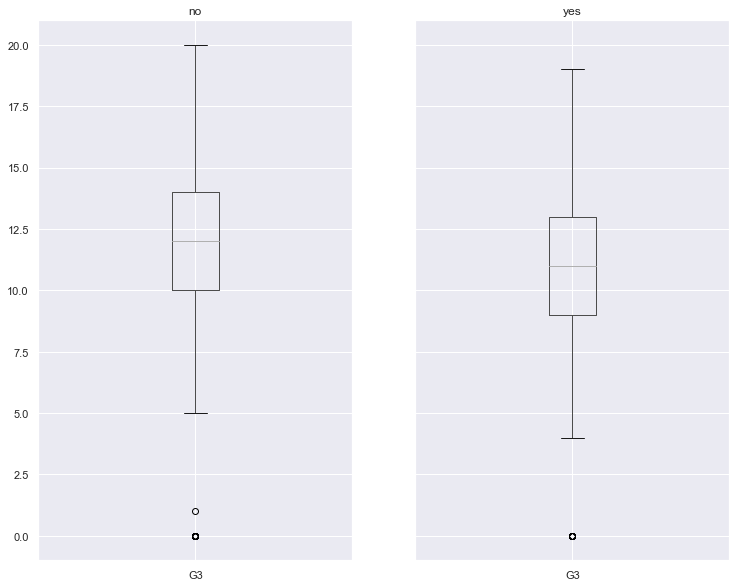

```python
data[['paid', 'G3']].groupby('paid').boxplot(figsize=(12, 10))
```

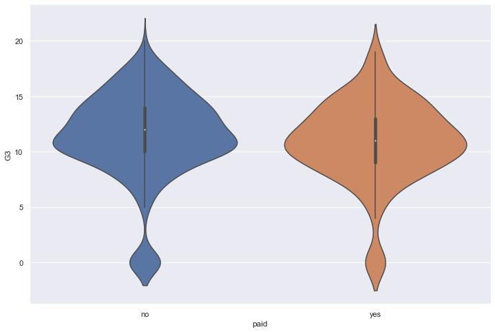

```python
sns.violinplot(x='paid', y='G3', data=data)
```

**Оценки тех, кто не имеет платных занятий, немного лучше**

```
no          AxesSubplot(0.1,0.15;0.363636x0.75)
yes    AxesSubplot(0.536364,0.15;0.363636x0.75)
dtype: object
```

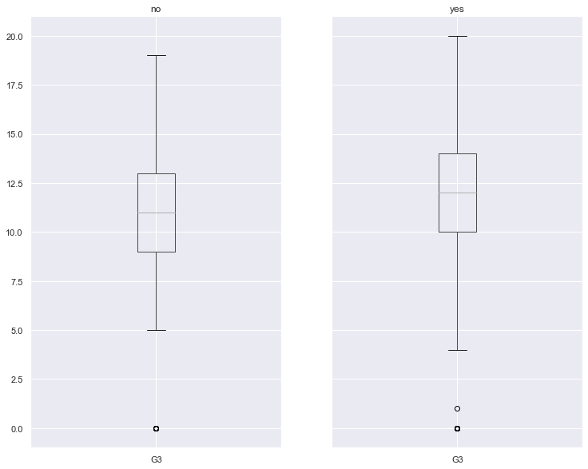

```python
data[['internet', 'G3']].groupby('internet').boxplot(figsize=(12, 10))
```

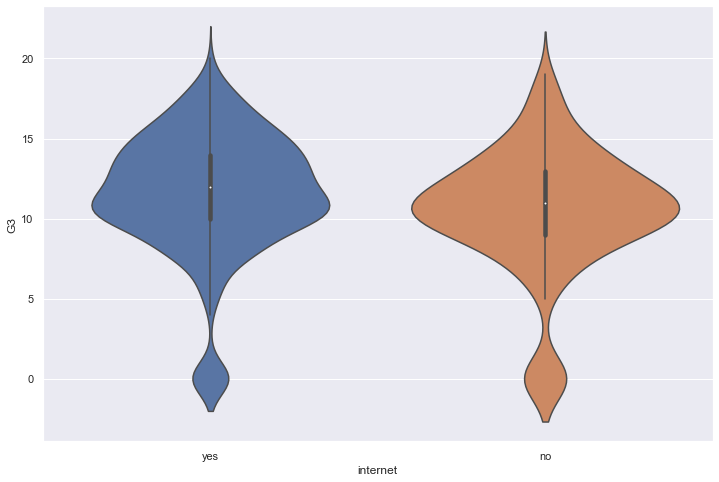

```python
sns.violinplot(x='internet', y='G3', data=data)
```

**Оценки тех, у кого есть доступ в интернет, в целом выше**

```
no          AxesSubplot(0.1,0.15;0.363636x0.75)
yes    AxesSubplot(0.536364,0.15;0.363636x0.75)
dtype: object
```

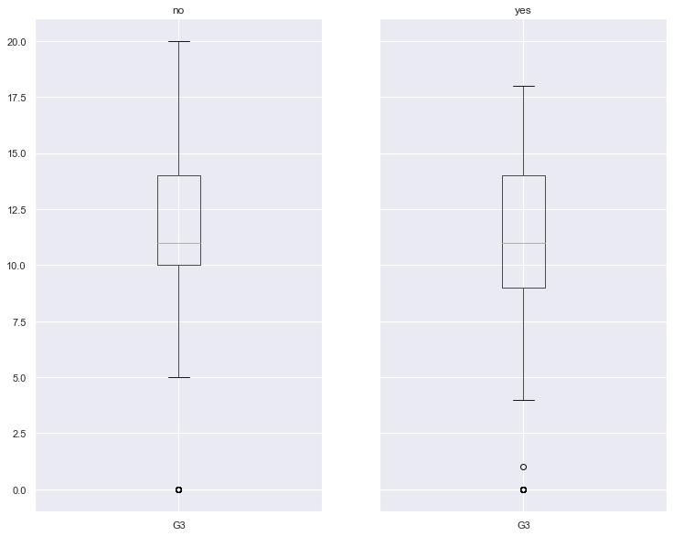

```python
data[['romantic', 'G3']].groupby('romantic').boxplot(figsize=(12, 10))
```

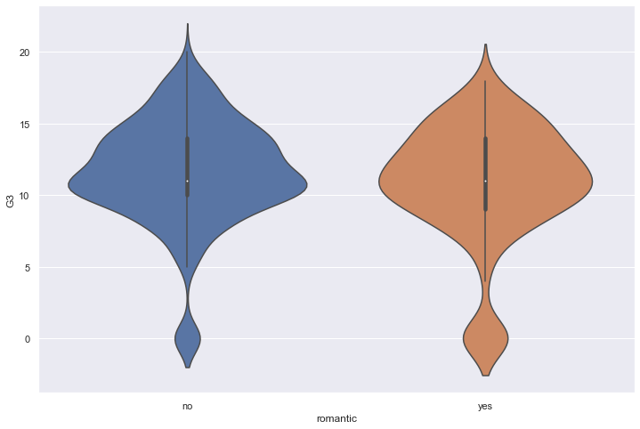

```python
sns.violinplot(x='romantic', y='G3', data=data)
```

**В среднем, оценки не сильно отличаются**

```
2.0          AxesSubplot(0.1,0.15;0.0754717x0.75)
3.0     AxesSubplot(0.190566,0.15;0.0754717x0.75)
4.0     AxesSubplot(0.281132,0.15;0.0754717x0.75)
5.0     AxesSubplot(0.371698,0.15;0.0754717x0.75)
6.0     AxesSubplot(0.462264,0.15;0.0754717x0.75)
7.0      AxesSubplot(0.55283,0.15;0.0754717x0.75)
8.0     AxesSubplot(0.643396,0.15;0.0754717x0.75)
9.0     AxesSubplot(0.733962,0.15;0.0754717x0.75)
10.0    AxesSubplot(0.824528,0.15;0.0754717x0.75)
dtype: object
```

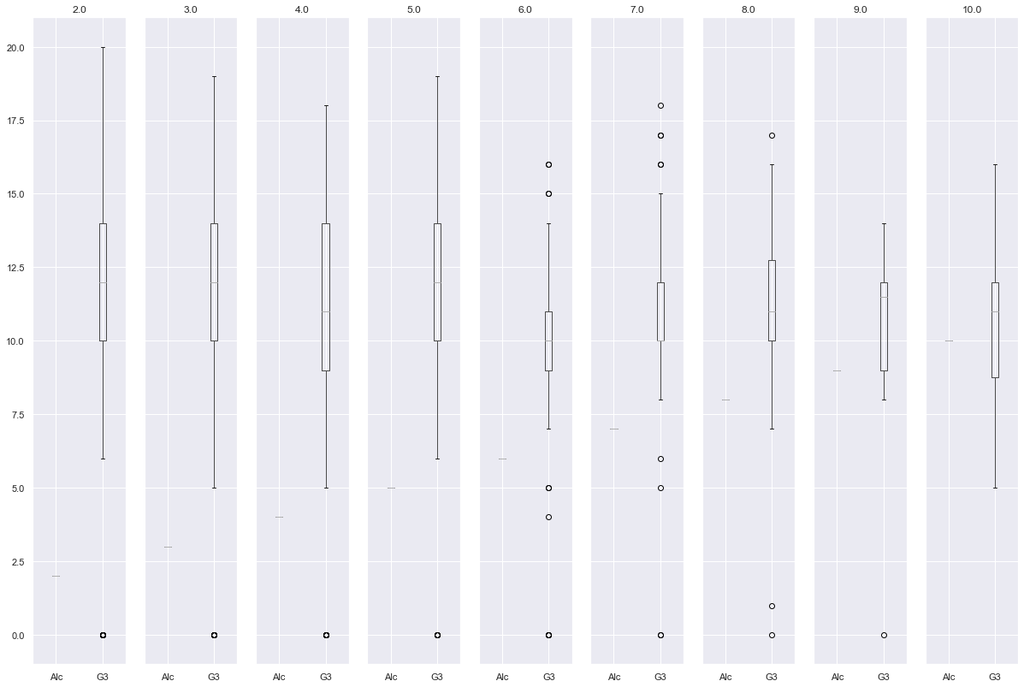

```python
data[['Alc', 'G3']].groupby('Alc').boxplot(layout=(1, 9), figsize=(20, 14))
```

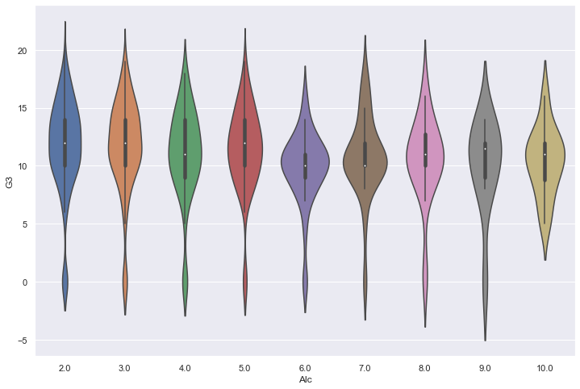

```python
sns.violinplot(x='Alc', y='G3', data=data)
```

**Малое количество выпитого алкоголя благополучено сказыаается на оценках**

```python
data = old_data.copy()
data['sup'] = [x or y or z for x, y in zip(data.famsup, data.schoolsup)]
```

### Задание 10

Добавьте в данные новый признак - итоговая оценка по 4-х балльной шкале:

- Отлично: 18 <= `G3` <= 20
- Хорошо: 14 <= `G3` <= 17
- Удовлетворительно: 8 <= `G3` <= 13
- Неудовлетворительно: `G3` < 8

Оцените распределение нового признака в зависимости от признака `reason` (причина выбора школы). Дайте содержательный комментарий.

```python
def mark(m: int):
    if 18 <= m <= 20:
        return 'Excellent'
    elif 14 <= m <= 17:
        return 'Good'
    elif 8 <= m <= 13:
        return 'Satisfactory'
    elif m < 8:
        return 'Unsatisfactory'

data['mark'] = [mark(x) for x in data.G3]
```

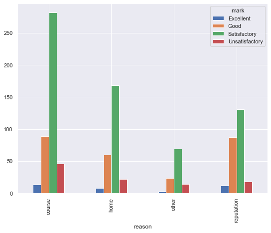

```python
pd.crosstab(index=data.reason, columns=data.mark, values=data.mark, aggfunc='count').plot.bar(figsize=(9, 7))
```

Как можно видеть, почему бы ни выбирали студенты школу, оценки у них были Удовлетворительные в большинстве случаев

Чаще всего школу выбирали из-за курса

Среди тех, у кого оценка Удовлетворительно, школа была выбрана из-за близости к дому чаще, чем из-за репутции, у Хорошистов - наоборот, репутация оказывалась важнее

### Задание 11

Часть из представленных в данных студентов посещали оба курса - `Math` и `Por`.

- Предложите способ идентификации студентов и определите тех, кто посещал оба курса. Сколько таких студентов?
- Для этих студентов сравните оценки по двум предметам, дайте комментарий.

**Note:** Столбец `ID` является уникальным идентификатором наблюдения, но не студента. Он будет уникален для каждой строки.

Первый вариант - сортировать по всем значениям, кроме тех, что непосредственно относятся к предмету (сам предмет, оценки, платные занятия, потому что только они относятся к предмету, а не к студенту). тогда ближайшие записи будут теми студентами,посещающими оба курса

Второй вариант - перебор каждого значения с поиском "пары" для него, отличающейся "предметными признаками"  
(то есть поиск по определению)

**Первый вариант**

Как можно видеть, получается немного не то, что хотелось

```python
taboo = ['Subject', 'paid', 'failures' 'G1', 'G2', 'G3', 'ID']

avail = list(set(data.columns) - set(taboo))

data_s = data.sort_values(by=avail, inplace=False)
data_s.index = data.index # reindexing
data_s.head(25)
```

|  | ID | Subject | school | sex | age | address | famsize | Pstatus | Medu | Fedu | Mjob | Fjob | reason | guardian | traveltime | studytime | failures | schoolsup | famsup | paid | activities | nursery | higher | internet | romantic | famrel | freetime | goout | Dalc | … |
| --- | --- | --- | --- | --- | --- | --- | --- | --- | --- | --- | --- | --- | --- | --- | --- | --- | --- | --- | --- | --- | --- | --- | --- | --- | --- | --- | --- | --- | --- | --- |
| 0 | 409459 | Por | GP | M | 15 | R | GT3 | T | 4 | 4 | other | other | home | father | 4 | 4 | 0 | no | yes | no | yes | yes | yes | yes | yes | 1.0 | 3 | 5 | 3.0 | … |
| 1 | 122585 | Math | GP | M | 15 | R | GT3 | T | 4 | 4 | other | other | home | father | 4 | 4 | 0 | no | yes | yes | yes | yes | yes | yes | yes | 1.0 | 3 | 5 | 3.0 | … |
| 2 | 712518 | Por | GP | M | 15 | U | GT3 | T | 4 | 3 | teacher | services | course | father | 2 | 4 | 0 | yes | yes | no | no | yes | yes | yes | no | 2.0 | 2 | 2 | 1.0 | … |
| 3 | 726849 | Math | GP | M | 15 | U | GT3 | T | 4 | 3 | teacher | services | course | father | 2 | 4 | 0 | yes | yes | no | no | yes | yes | yes | no | 2.0 | 2 | 2 | 1.0 | … |
| 4 | 636379 | Por | GP | F | 15 | U | GT3 | T | 1 | 2 | at_home | services | course | father | 1 | 2 | 0 | no | no | no | no | no | yes | no | yes | 2.0 | 3 | 4 | 2.0 | … |
| 5 | 357371 | Por | GP | M | 16 | U | LE3 | T | 2 | 2 | services | services | reputation | father | 2 | 1 | 0 | no | yes | no | yes | yes | yes | yes | no | 2.0 | 3 | 3 | 2.0 | … |
| 6 | 156179 | Por | MS | F | 18 | U | GT3 | A | 2 | 4 | other | services | reputation | father | 1 | 2 | 1 | no | yes | no | no | yes | yes | yes | no | 2.0 | 3 | 2 | 1.0 | … |
| 7 | 905688 | Math | GP | M | 16 | U | LE3 | T | 2 | 2 | services | services | reputation | father | 2 | 1 | 2 | no | yes | no | yes | yes | yes | yes | no | 2.0 | 3 | 3 | 2.0 | … |
| 8 | 328352 | Por | MS | F | 17 | U | GT3 | T | 0 | 1 | other | at_home | course | father | 2 | 1 | 0 | no | no | no | yes | no | yes | no | no | 2.0 | 4 | 4 | 3.0 | … |
| 9 | 221759 | Math | GP | F | 18 | U | GT3 | T | 4 | 4 | health | health | reputation | father | 1 | 2 | 1 | yes | yes | no | yes | yes | yes | yes | yes | 2.0 | 4 | 4 | 1.0 | … |
| 10 | 263901 | Por | GP | F | 18 | U | GT3 | T | 4 | 4 | health | health | reputation | father | 1 | 2 | 1 | yes | yes | no | yes | yes | yes | yes | yes | 2.0 | 4 | 4 | 1.0 | … |
| 11 | 695277 | Math | GP | F | 18 | U | GT3 | T | 4 | 3 | services | other | home | father | 1 | 2 | 0 | no | yes | yes | no | yes | yes | yes | yes | 3.0 | 1 | 2 | 1.0 | … |
| 12 | 223229 | Por | GP | F | 18 | U | GT3 | T | 4 | 3 | services | other | home | father | 1 | 2 | 0 | no | yes | no | no | yes | yes | yes | yes | 3.0 | 1 | 2 | 1.0 | … |
| 13 | 889769 | Math | GP | M | 16 | U | LE3 | T | 4 | 3 | health | other | home | father | 1 | 1 | 0 | no | no | yes | yes | yes | yes | yes | no | 3.0 | 1 | 3 | 1.0 | … |
| 14 | 569359 | Por | GP | M | 16 | U | LE3 | T | 4 | 3 | health | other | home | father | 1 | 1 | 0 | no | no | no | yes | yes | yes | yes | no | 3.0 | 1 | 3 | 1.0 | … |
| 15 | 453908 | Por | GP | M | 18 | R | GT3 | T | 2 | 3 | other | services | reputation | father | 1 | 1 | 0 | no | no | no | no | yes | yes | yes | no | 3.0 | 1 | 3 | 4.0 | … |
| 16 | 100097 | Por | GP | F | 16 | U | GT3 | A | 3 | 4 | services | other | course | father | 1 | 1 | 0 | no | no | no | no | yes | yes | yes | no | 3.0 | 2 | 1 | 1.0 | … |
| 17 | 457807 | Por | GP | M | 15 | U | GT3 | T | 2 | 3 | other | services | course | father | 1 | 1 | 0 | yes | yes | no | yes | no | yes | yes | yes | 3.0 | 2 | 2 | 1.0 | … |
| 18 | 235285 | Math | GP | M | 15 | U | GT3 | T | 2 | 3 | other | services | course | father | 1 | 1 | 0 | yes | yes | yes | yes | no | yes | yes | yes | 3.0 | 2 | 2 | 1.0 | … |
| 19 | 280327 | Math | GP | F | 16 | U | GT3 | A | 3 | 4 | services | other | course | father | 1 | 1 | 0 | no | no | no | no | yes | yes | yes | no | 3.0 | 2 | 1 | 1.0 | … |
| 20 | 819030 | Math | MS | F | 17 | R | GT3 | T | 1 | 2 | other | services | course | father | 2 | 2 | 0 | no | no | no | no | no | yes | no | no | 3.0 | 2 | 2 | 1.0 | … |
| 21 | 132104 | Por | MS | F | 17 | R | GT3 | T | 1 | 2 | other | services | course | father | 2 | 2 | 0 | no | no | no | no | no | yes | no | no | 3.0 | 2 | 2 | 1.0 | … |
| 22 | 200914 | Math | MS | M | 19 | U | LE3 | T | 1 | 1 | other | at_home | course | father | 1 | 1 | 0 | no | no | no | no | yes | yes | yes | no | 3.0 | 2 | 3 | 3.0 | … |
| 23 | 516232 | Por | MS | M | 18 | U | GT3 | T | 4 | 4 | teacher | teacher | home | father | 1 | 2 | 0 | no | no | no | yes | no | yes | yes | no | 3.0 | 2 | 4 | 1.0 | … |
| 24 | 342108 | Math | MS | M | 18 | U | GT3 | T | 4 | 4 | teacher | teacher | home | father | 1 | 2 | 0 | no | no | yes | yes | no | yes | yes | no | 3.0 | 2 | 4 | 1.0 | … |

Можно выводить только те записи, у которых сверху - Por, снизу - Math. Таким образом мы получим записи, подозрительные на принадлежность одному студенту.

```python
data_s_paired = pd.DataFrame(columns=data_s.columns)

t = 0

for i in range(len(data_s) - 1):
    if data_s.loc[i]['Subject'] == 'Por' and data_s.loc[i + 1]['Subject'] == 'Math':

        data_s_paired.loc[t] = list(data_s.loc[i])
        t += 1
        data_s_paired.loc[t] = list(data_s.loc[i + 1])
        t += 1

data_s_paired
```

|  | ID | Subject | school | sex | age | address | famsize | Pstatus | Medu | Fedu | Mjob | Fjob | reason | guardian | traveltime | studytime | failures | schoolsup | famsup | paid | activities | nursery | higher | internet | romantic | famrel | freetime | goout | Dalc | … |
| --- | --- | --- | --- | --- | --- | --- | --- | --- | --- | --- | --- | --- | --- | --- | --- | --- | --- | --- | --- | --- | --- | --- | --- | --- | --- | --- | --- | --- | --- | --- |
| 0 | 409459 | Por | GP | M | 15 | R | GT3 | T | 4 | 4 | other | other | home | father | 4 | 4 | 0 | no | yes | no | yes | yes | yes | yes | yes | 1.0 | 3 | 5 | 3.0 | … |
| 1 | 122585 | Math | GP | M | 15 | R | GT3 | T | 4 | 4 | other | other | home | father | 4 | 4 | 0 | no | yes | yes | yes | yes | yes | yes | yes | 1.0 | 3 | 5 | 3.0 | … |
| 2 | 712518 | Por | GP | M | 15 | U | GT3 | T | 4 | 3 | teacher | services | course | father | 2 | 4 | 0 | yes | yes | no | no | yes | yes | yes | no | 2.0 | 2 | 2 | 1.0 | … |
| 3 | 726849 | Math | GP | M | 15 | U | GT3 | T | 4 | 3 | teacher | services | course | father | 2 | 4 | 0 | yes | yes | no | no | yes | yes | yes | no | 2.0 | 2 | 2 | 1.0 | … |
| 4 | 156179 | Por | MS | F | 18 | U | GT3 | A | 2 | 4 | other | services | reputation | father | 1 | 2 | 1 | no | yes | no | no | yes | yes | yes | no | 2.0 | 3 | 2 | 1.0 | … |
| ... | ... | ... | ... | ... | ... | ... | ... | ... | ... | ... | ... | ... | ... | ... | ... | ... | ... | ... | ... | ... | ... | ... | ... | ... | ... | ... | ... | ... | ... | … |
| 611 | 890351 | Math | MS | M | 19 | R | GT3 | T | 1 | 1 | other | services | home | other | 3 | 2 | 3 | no | no | no | no | yes | yes | yes | no | 5.0 | 4 | 4 | 3.0 | … |
| 612 | 390717 | Por | GP | M | 20 | U | GT3 | A | 3 | 2 | services | other | course | other | 1 | 1 | 2 | no | no | no | yes | yes | yes | no | no | 5.0 | 5 | 3 | 1.0 | … |
| 613 | 417336 | Math | MS | M | 20 | U | LE3 | A | 2 | 2 | services | services | course | other | 1 | 2 | 2 | no | yes | yes | no | yes | yes | no | no | 5.0 | 5 | 4 | 4.0 | … |
| 614 | 504919 | Por | GP | F | 19 | U | LE3 | A | 2 | 3 | at_home | other | home | other | 2 | 1 | 1 | no | no | no | no | yes | no | yes | no | NaN | 2 | 3 | 3.0 | … |
| 615 | 469435 | Math | MS | M | 19 | R | GT3 | T | 1 | 1 | other | other | home | other | 3 | 1 | 1 | no | yes | no | no | yes | yes | yes | no | NaN | 4 | 4 | 3.0 | … |

616 rows × 39 columns

```python
data_s_paired.head(20)
```

|  | ID | Subject | school | sex | age | address | famsize | Pstatus | Medu | Fedu | Mjob | Fjob | reason | guardian | traveltime | studytime | failures | schoolsup | famsup | paid | activities | nursery | higher | internet | romantic | famrel | freetime | goout | Dalc | … |
| --- | --- | --- | --- | --- | --- | --- | --- | --- | --- | --- | --- | --- | --- | --- | --- | --- | --- | --- | --- | --- | --- | --- | --- | --- | --- | --- | --- | --- | --- | --- |
| 0 | 409459 | Por | GP | M | 15 | R | GT3 | T | 4 | 4 | other | other | home | father | 4 | 4 | 0 | no | yes | no | yes | yes | yes | yes | yes | 1.0 | 3 | 5 | 3.0 | … |
| 1 | 122585 | Math | GP | M | 15 | R | GT3 | T | 4 | 4 | other | other | home | father | 4 | 4 | 0 | no | yes | yes | yes | yes | yes | yes | yes | 1.0 | 3 | 5 | 3.0 | … |
| 2 | 712518 | Por | GP | M | 15 | U | GT3 | T | 4 | 3 | teacher | services | course | father | 2 | 4 | 0 | yes | yes | no | no | yes | yes | yes | no | 2.0 | 2 | 2 | 1.0 | … |
| 3 | 726849 | Math | GP | M | 15 | U | GT3 | T | 4 | 3 | teacher | services | course | father | 2 | 4 | 0 | yes | yes | no | no | yes | yes | yes | no | 2.0 | 2 | 2 | 1.0 | … |
| 4 | 156179 | Por | MS | F | 18 | U | GT3 | A | 2 | 4 | other | services | reputation | father | 1 | 2 | 1 | no | yes | no | no | yes | yes | yes | no | 2.0 | 3 | 2 | 1.0 | … |
| 5 | 905688 | Math | GP | M | 16 | U | LE3 | T | 2 | 2 | services | services | reputation | father | 2 | 1 | 2 | no | yes | no | yes | yes | yes | yes | no | 2.0 | 3 | 3 | 2.0 | … |
| 6 | 328352 | Por | MS | F | 17 | U | GT3 | T | 0 | 1 | other | at_home | course | father | 2 | 1 | 0 | no | no | no | yes | no | yes | no | no | 2.0 | 4 | 4 | 3.0 | … |
| 7 | 221759 | Math | GP | F | 18 | U | GT3 | T | 4 | 4 | health | health | reputation | father | 1 | 2 | 1 | yes | yes | no | yes | yes | yes | yes | yes | 2.0 | 4 | 4 | 1.0 | … |
| 8 | 263901 | Por | GP | F | 18 | U | GT3 | T | 4 | 4 | health | health | reputation | father | 1 | 2 | 1 | yes | yes | no | yes | yes | yes | yes | yes | 2.0 | 4 | 4 | 1.0 | … |
| 9 | 695277 | Math | GP | F | 18 | U | GT3 | T | 4 | 3 | services | other | home | father | 1 | 2 | 0 | no | yes | yes | no | yes | yes | yes | yes | 3.0 | 1 | 2 | 1.0 | … |
| 10 | 223229 | Por | GP | F | 18 | U | GT3 | T | 4 | 3 | services | other | home | father | 1 | 2 | 0 | no | yes | no | no | yes | yes | yes | yes | 3.0 | 1 | 2 | 1.0 | … |
| 11 | 889769 | Math | GP | M | 16 | U | LE3 | T | 4 | 3 | health | other | home | father | 1 | 1 | 0 | no | no | yes | yes | yes | yes | yes | no | 3.0 | 1 | 3 | 1.0 | … |
| 12 | 457807 | Por | GP | M | 15 | U | GT3 | T | 2 | 3 | other | services | course | father | 1 | 1 | 0 | yes | yes | no | yes | no | yes | yes | yes | 3.0 | 2 | 2 | 1.0 | … |
| 13 | 235285 | Math | GP | M | 15 | U | GT3 | T | 2 | 3 | other | services | course | father | 1 | 1 | 0 | yes | yes | yes | yes | no | yes | yes | yes | 3.0 | 2 | 2 | 1.0 | … |
| 14 | 132104 | Por | MS | F | 17 | R | GT3 | T | 1 | 2 | other | services | course | father | 2 | 2 | 0 | no | no | no | no | no | yes | no | no | 3.0 | 2 | 2 | 1.0 | … |
| 15 | 200914 | Math | MS | M | 19 | U | LE3 | T | 1 | 1 | other | at_home | course | father | 1 | 1 | 0 | no | no | no | no | yes | yes | yes | no | 3.0 | 2 | 3 | 3.0 | … |
| 16 | 516232 | Por | MS | M | 18 | U | GT3 | T | 4 | 4 | teacher | teacher | home | father | 1 | 2 | 0 | no | no | no | yes | no | yes | yes | no | 3.0 | 2 | 4 | 1.0 | … |
| 17 | 342108 | Math | MS | M | 18 | U | GT3 | T | 4 | 4 | teacher | teacher | home | father | 1 | 2 | 0 | no | no | yes | yes | no | yes | yes | no | 3.0 | 2 | 4 | 1.0 | … |
| 18 | 422011 | Por | GP | M | 18 | U | LE3 | T | 3 | 3 | services | health | home | father | 1 | 2 | 0 | no | yes | no | no | yes | yes | yes | no | 3.0 | 2 | 4 | 2.0 | … |
| 19 | 897095 | Math | GP | M | 18 | U | LE3 | T | 3 | 3 | services | health | home | father | 1 | 2 | 1 | no | yes | yes | no | yes | yes | yes | no | 3.0 | 2 | 4 | 2.0 | … |

**Второй подход**  
Поиск похожий записей по определнию (сложность O(k*n<sup>2</sup>), k - число признаков, n - число записей; работает очень долго)

```python
def is_similar(row1, row2):
    for col in avail:
        if row1[col] != row2[col]:
            return False
    return True
```

```python
similar = pd.DataFrame(columns=['new_id'] + list(data.columns))

t = 0
new_id = 0

for i in range(len(data) - 1):
    for j in range(len(data) - 1):
        if i != j and is_similar(data.loc[i], data.loc[j]):
            similar.loc[t] = [new_id] + list(data.loc[i])
            t += 1
            similar.loc[t] = [new_id] + list(data.loc[j])
            t += 1
            new_id += 1

similar
```

|  | new_id | ID | Subject | school | sex | age | address | famsize | Pstatus | Medu | Fedu | Mjob | Fjob | reason | guardian | traveltime | studytime | failures | schoolsup | famsup | paid | activities | nursery | higher | internet | romantic | famrel | freetime | goout | … |
| --- | --- | --- | --- | --- | --- | --- | --- | --- | --- | --- | --- | --- | --- | --- | --- | --- | --- | --- | --- | --- | --- | --- | --- | --- | --- | --- | --- | --- | --- | --- |
| 0 | 0 | 257390 | Math | GP | F | 15 | U | GT3 | A | 3 | 3 | other | health | reputation | father | 1 | 4 | 0 | yes | no | no | no | yes | yes | no | no | 4.0 | 3 | 3 | … |
| 1 | 0 | 746312 | Por | GP | F | 15 | U | GT3 | A | 3 | 3 | other | health | reputation | father | 1 | 4 | 0 | yes | no | no | no | yes | yes | no | no | 4.0 | 3 | 3 | … |
| 2 | 1 | 746312 | Por | GP | F | 15 | U | GT3 | A | 3 | 3 | other | health | reputation | father | 1 | 4 | 0 | yes | no | no | no | yes | yes | no | no | 4.0 | 3 | 3 | … |
| 3 | 1 | 257390 | Math | GP | F | 15 | U | GT3 | A | 3 | 3 | other | health | reputation | father | 1 | 4 | 0 | yes | no | no | no | yes | yes | no | no | 4.0 | 3 | 3 | … |

```python
similar.drop_duplicates(subset=data.columns)
```

|  | new_id | ID | Subject | school | sex | age | address | famsize | Pstatus | Medu | Fedu | Mjob | Fjob | reason | guardian | traveltime | studytime | failures | schoolsup | famsup | paid | activities | nursery | higher | internet | romantic | famrel | freetime | goout | … |
| --- | --- | --- | --- | --- | --- | --- | --- | --- | --- | --- | --- | --- | --- | --- | --- | --- | --- | --- | --- | --- | --- | --- | --- | --- | --- | --- | --- | --- | --- | --- |
| 0 | 0 | 257390 | Math | GP | F | 15 | U | GT3 | A | 3 | 3 | other | health | reputation | father | 1 | 4 | 0 | yes | no | no | no | yes | yes | no | no | 4.0 | 3 | 3 | … |
| 1 | 0 | 746312 | Por | GP | F | 15 | U | GT3 | A | 3 | 3 | other | health | reputation | father | 1 | 4 | 0 | yes | no | no | no | yes | yes | no | no | 4.0 | 3 | 3 | … |

Получилось совсем немного студентов, посещающих и математику, и португальский язык

```python
similar = similar.drop_duplicates(subset=data.columns)
students_both = {}
for i in range(0, len(similar) - 1, 2):
    students_both[similar.loc[i]['new_id']] = {
        'ids': [similar.loc[i]['ID'], similar.loc[i + 1]['ID']],
        'Math': [similar.loc[i]['G1'], similar.loc[i]['G2'], similar.loc[i]['G3']],
        'Por': [similar.loc[i + 1]['G1'], similar.loc[i + 1]['G2'], similar.loc[i + 1]['G3']]
    }

students_both
```

```
{0: {'ids': [257390, 746312], 'Math': [10, 11, 11], 'Por': [10, 10, 10]}}
```

### Задание 12

Предложите простую модель для определения (предсказания) итоговой оценки студента по 4-х балльной системе. Оцените точность предложенной модели.

```python
# здесь будут оценки G1, G2 и результат, к которому будем стремится

marks = data[['G1', 'G2', 'mark']]
marks
```

|  | G1 | G2 | mark |
| --- | --- | --- | --- |
| 0 | 15 | 13 | Good |
| 1 | 17 | 18 | Good |
| 2 | 9 | 8 | Satisfactory |
| 3 | 14 | 15 | Good |
| 4 | 12 | 13 | Satisfactory |
| ... | ... | ... | ... |
| 1039 | 10 | 10 | Satisfactory |
| 1040 | 10 | 9 | Satisfactory |
| 1041 | 16 | 17 | Excellent |
| 1042 | 9 | 9 | Satisfactory |
| 1043 | 12 | 11 | Satisfactory |

1044 rows × 3 columns

Вспомним, какие границы присущи маркерам оценок:

- Отлично: 18 <= G3 <= 20
- Хорошо: 14 <= G3 <= 17
- Удовлетворительно: 8 <= G3 <= 13
- Неудовлетворительно: G3 < 8

```python
# создадим колонку "среднее" в marks

marks['mean'] = [(x + y) / 2 for x, y in zip(marks.G1, marks.G2)]
```

```python
# проставим новые "маркеры"

marks['new_marks'] = [mark(x) for x in marks['mean']]
marks
```

|  | G1 | G2 | mark | mean | new_marks |
| --- | --- | --- | --- | --- | --- |
| 0 | 15 | 13 | Good | 14.0 | Good |
| 1 | 17 | 18 | Good | 17.5 | None |
| 2 | 9 | 8 | Satisfactory | 8.5 | Satisfactory |
| 3 | 14 | 15 | Good | 14.5 | Good |
| 4 | 12 | 13 | Satisfactory | 12.5 | Satisfactory |
| ... | ... | ... | ... | ... | ... |
| 1039 | 10 | 10 | Satisfactory | 10.0 | Satisfactory |
| 1040 | 10 | 9 | Satisfactory | 9.5 | Satisfactory |
| 1041 | 16 | 17 | Excellent | 16.5 | Good |
| 1042 | 9 | 9 | Satisfactory | 9.0 | Satisfactory |
| 1043 | 12 | 11 | Satisfactory | 11.5 | Satisfactory |

1044 rows × 5 columns

```python
# сравним mark и new_mark

eq_marks = [x == y for x, y in zip(marks.mark, marks.new_marks)]

sum([1 if x else 0 for x in eq_marks]) / len(eq_marks)
```

```
0.8103448275862069
```

Оценка получилась вполне правдивой

### Задание * (бонусное)

Дополнительное исследование данных и выводы положительно скажутся на оценке.

### Рассмотрим влияние образования родителей на выбор школы детей

- Medu Образование матери: 0 - без образования, 1 - начальная школа, 2 – от 5 до 9 классов, 3 – среднее образование, 4 – высшее образование
- Fedu Образование отца: 0 - без образования, 1 - начальная школа, 2 – от 5 до 9 классов, 3 – среднее образование, 4 – высшее образование

```python
from sklearn.preprocessing import LabelEncoder
```

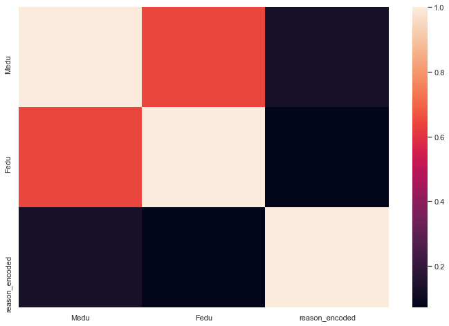

```python
reasons = LabelEncoder().fit_transform(data.reason)
data['reason_encoded'] = reasons

sns.heatmap(data[['Medu', 'Fedu', 'reason_encoded']].corr())
```

**Как видно по матрице корреляции, образование родителей не влияет на причину выбора школы. Однако интересные наблюдения будут дальше**

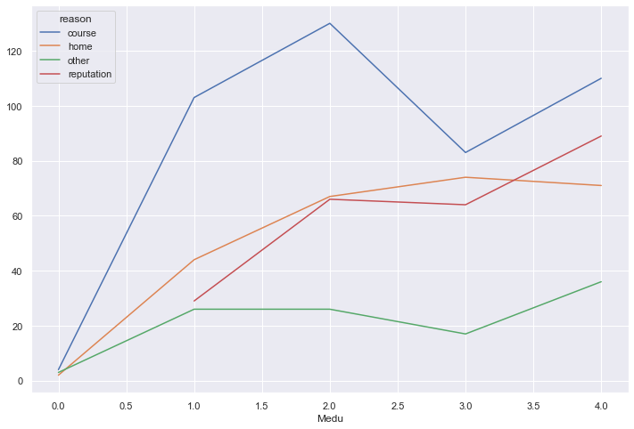

```python
pd.crosstab(index=data.Medu, columns=data.reason, values=data.reason, aggfunc='count').plot()
```

**Как можно видеть, при "смене" образования матери со среднего на высшее, меняется причина выбора школы. Если при среднем чаще выбирали школу по близости к дому, то при высшем - из-за репутации**

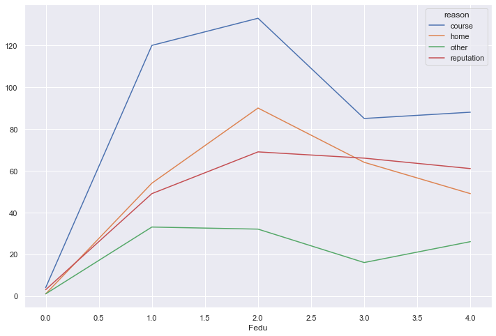

```python
pd.crosstab(index=data.Fedu, columns=data.reason, values=data.reason, aggfunc='count').plot()
```

### Рассмотрим влияние работы родителей

- Mjob Работа матери: 'teacher' - связана с преподаванием, 'health' - связана с здравоохранением, 'services' - администрация и полиция, 'at_home' - домашняя занятость, 'other' - другое
- Fjob Работа отца: 'teacher' - связана с преподаванием, 'health' - связана с здравоохранением, 'services' - администрация и полиция, 'at_home' - домашняя занятость, 'other' - другое

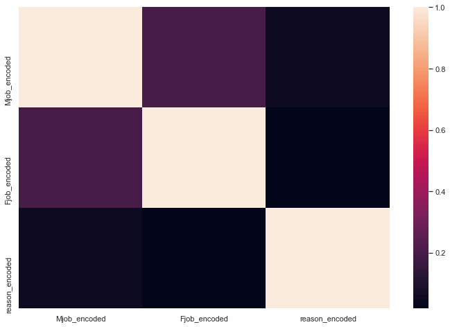

```python
mjob = LabelEncoder().fit_transform(data.Mjob)
fjob = LabelEncoder().fit_transform(data.Fjob)

data['Mjob_encoded'] = mjob
data['Fjob_encoded'] = fjob

sns.heatmap(data[['Mjob_encoded', 'Fjob_encoded', 'reason_encoded']].corr())
```

**Работа родителей не влиеяет на причины выбора школы**

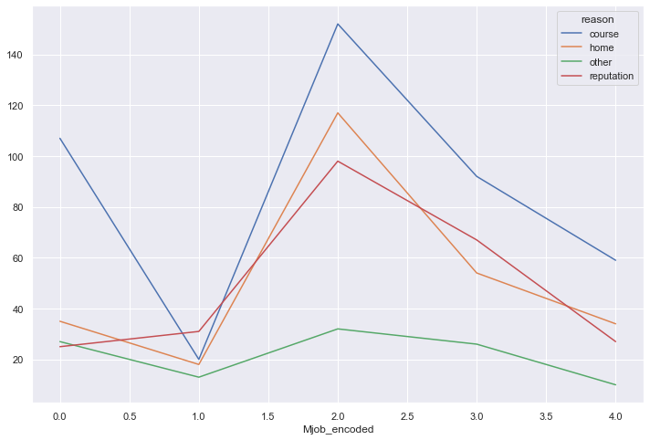

```python
pd.crosstab(index=data.Mjob_encoded, columns=data.reason, values=data.reason, aggfunc='count').plot()
```

```python
print(sorted(data.Mjob.unique()))
print(sorted(data.Mjob_encoded.unique()))
data[['Mjob', 'Mjob_encoded']]
```

```
['at_home', 'health', 'other', 'services', 'teacher']
[0, 1, 2, 3, 4]
```

|  | Mjob | Mjob_encoded |
| --- | --- | --- |
| 0 | services | 3 |
| 1 | other | 2 |
| 2 | health | 1 |
| 3 | other | 2 |
| 4 | at_home | 0 |
| ... | ... | ... |
| 1039 | services | 3 |
| 1040 | health | 1 |
| 1041 | at_home | 0 |
| 1042 | at_home | 0 |
| 1043 | other | 2 |

1044 rows × 2 columns

**Дети мам - государственных служащих и полицейских - выбирают школу чаще из-за репутации, чем из-за близости к дому, а дети мам, которые работают учителями или имеют другие професии - наоборот. А дети мам-врачей обращают на курс меньше внимания, чем другие дети**

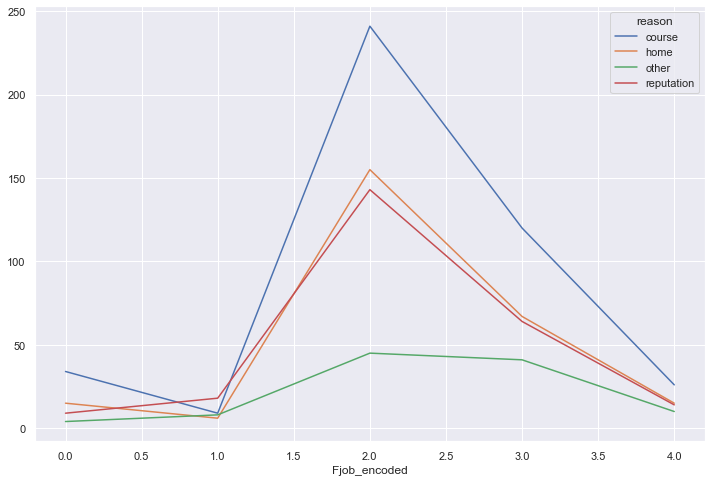

```python
pd.crosstab(index=data.Fjob_encoded, columns=data.reason, values=data.reason, aggfunc='count').plot()
```

```python
print(sorted(data.Fjob.unique()))
print(sorted(data.Fjob_encoded.unique()))
data[['Fjob', 'Fjob_encoded']]
```

```
['at_home', 'health', 'other', 'services', 'teacher']
[0, 1, 2, 3, 4]
```

|  | Fjob | Fjob_encoded |
| --- | --- | --- |
| 0 | other | 2 |
| 1 | other | 2 |
| 2 | services | 3 |
| 3 | services | 3 |
| 4 | other | 2 |
| ... | ... | ... |
| 1039 | services | 3 |
| 1040 | services | 3 |
| 1041 | other | 2 |
| 1042 | other | 2 |
| 1043 | other | 2 |

1044 rows × 2 columns

**С другой стороны, профессия отца не сильно влияет на причину выбора школы, а курс всё также не самая популярная причина выборы школы среди детей пап-врачей**